# Dayananda_201EC219_Panda_and_scikit Library

```python
import matplotlib.pyplot as plt
import numpy as np
import seaborn as sns
import pandas as pd
from pandas import DataFrame , read_csv
#%matplotlib inline
```

```python
# creating a dictionary
d = {'one' : pd.Series([1.,2.,3.,4.0] , index = ['a','b','c','d']),
     'two' : pd.Series([1.,2.,3.,4.0], index = ['a','b','c','d'])}
# creating Data frame
df = pd.DataFrame(d)
df
```

|  | one | two |
| --- | --- | --- |
| a | 1.0 | 1.0 |
| b | 2.0 | 2.0 |
| c | 3.0 | 3.0 |
| d | 4.0 | 4.0 |

```python
df.shape
df.dtypes
```

```
one    float64
two    float64
dtype: object
```

```python
# creating the Data Range
dates = pd.date_range('20230828', periods = 10)
dates
```

```
DatetimeIndex(['2023-08-28', '2023-08-29', '2023-08-30', '2023-08-31',
               '2023-09-01', '2023-09-02', '2023-09-03', '2023-09-04',
               '2023-09-05', '2023-09-06'],
              dtype='datetime64[ns]', freq='D')
```

```python
df2 = pd.DataFrame(np.random.randn(10,5),index = dates, columns = list('ABCDE'))
df2.head()
```

|  | A | B | C | D | E |
| --- | --- | --- | --- | --- | --- |
| 2023-08-28 | -1.259220 | -0.113396 | -1.033732 | -0.421034 | -2.403980 |
| 2023-08-29 | 0.660671 | -0.629648 | 1.060357 | -0.954208 | 0.211013 |
| 2023-08-30 | 0.682445 | -0.912921 | -0.365435 | 0.624983 | -0.671925 |
| 2023-08-31 | -0.818706 | -1.251755 | -0.280952 | 0.464451 | 1.665456 |
| 2023-09-01 | 1.284641 | 0.541382 | -0.525411 | -0.548460 | 0.041907 |

```python
# THE data merging example

names = ['Bob','Jessica','Marry','John','Mel']
births = [968,155,77,578,973]

# To merge  these two lists  together  we will use  the zip function

BabyDataSet = list(zip(names,births))
print(BabyDataSet)
```

```
[('Bob', 968), ('Jessica', 155), ('Marry', 77), ('John', 578), ('Mel', 973)]
```

```python
# PANDAS  CREATE A DATA FRAME AND WRITE  TO CSV FILE

df3 = pd.DataFrame(data = BabyDataSet, columns = ['Names','Births'])
#df3.to_csv('Births1880.csv', index = False, header = False)
df3.to_csv('/home/dayananda/Documents/NNDL/PANDAS_Library_with_applications/Births1880_anotherway.csv',index = False, header = False)
```

#### READING THE DATA FROM CSV FILE

- df = pd.read_csv(filename)
- Don't treat the first row as header
- df = pd.read_csv(Location,header = None)
- Provide specific name for columns
- df = pd.read_csv(Locatoin, names = ['Names','Births'])

```python
df4 = pd.read_csv('/home/dayananda/Documents/NNDL/PANDAS_Library_with_applications/Births1880_anotherway.csv', names = ['Names','Births'])
df4
```

|  | Names | Births |
| --- | --- | --- |
| 0 | Bob | 968 |
| 1 | Jessica | 155 |
| 2 | Marry | 77 |
| 3 | John | 578 |
| 4 | Mel | 973 |

#### Pandas - Get data types

```python
df4.dtypes
```

```
Names     object
Births     int64
dtype: object
```

```python
df4.Births.dtypes
```

```
dtype('int64')
```

```python
df4.Names.dtypes
```

```
dtype('O')
```

#### Pandas - Take a look at the data

```python
df4.head()
```

|  | Names | Births |
| --- | --- | --- |
| 0 | Bob | 968 |
| 1 | Jessica | 155 |
| 2 | Marry | 77 |
| 3 | John | 578 |
| 4 | Mel | 973 |

```python
df4.head(1)
```

|  | Names | Births |
| --- | --- | --- |
| 0 | Bob | 968 |

```python
df4.head(2)
```

|  | Names | Births |
| --- | --- | --- |
| 0 | Bob | 968 |
| 1 | Jessica | 155 |

```python
df4.head(3)
```

|  | Names | Births |
| --- | --- | --- |
| 0 | Bob | 968 |
| 1 | Jessica | 155 |
| 2 | Marry | 77 |

```python
df4.head(4)
```

|  | Names | Births |
| --- | --- | --- |
| 0 | Bob | 968 |
| 1 | Jessica | 155 |
| 2 | Marry | 77 |
| 3 | John | 578 |

```python
df4.head(5)
```

|  | Names | Births |
| --- | --- | --- |
| 0 | Bob | 968 |
| 1 | Jessica | 155 |
| 2 | Marry | 77 |
| 3 | John | 578 |
| 4 | Mel | 973 |

```python
df4.head(-1)
```

|  | Names | Births |
| --- | --- | --- |
| 0 | Bob | 968 |
| 1 | Jessica | 155 |
| 2 | Marry | 77 |
| 3 | John | 578 |

```python
df4.head(-2)
```

|  | Names | Births |
| --- | --- | --- |
| 0 | Bob | 968 |
| 1 | Jessica | 155 |
| 2 | Marry | 77 |

```python
df4.head(-3)
```

|  | Names | Births |
| --- | --- | --- |
| 0 | Bob | 968 |
| 1 | Jessica | 155 |

```python
df4.head(-4)
```

|  | Names | Births |
| --- | --- | --- |
| 0 | Bob | 968 |

```python
df4.head(-5)
```

|  | Names | Births |
| --- | --- | --- |

```python
df4.columns
```

```
Index(['Names', 'Births'], dtype='object')
```

```python
df4.values
```

```
array([['Bob', 968],
       ['Jessica', 155],
       ['Marry', 77],
       ['John', 578],
       ['Mel', 973]], dtype=object)
```

```python
df4.index
```

```
RangeIndex(start=0, stop=5, step=1)
```

#### Pandas -Working on the data

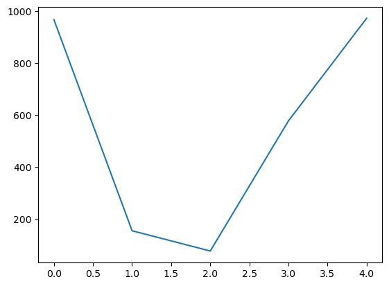

```python
df4_plot = df4['Births'].plot()
```

```python
MinValue  = df4['Births'].min()
MinValue
```

```
77
```

```python
MaxValue = df4['Births'].max()
MaxValue
```

```
973
```

#### Pandas - Describe the data

```python
df4['Names'].unique()
```

```
array(['Bob', 'Jessica', 'Marry', 'John', 'Mel'], dtype=object)
```

```python
print(df4['Names'].describe())
```

```
count       5
unique      5
top       Bob
freq        1
Name: Names, dtype: object
```

```python
df5 = pd.read_table('/home/dayananda/Documents/NNDL/PANDAS_Library_with_applications/Pandas_Scikit_DrShyam_NITK/Data/data.txt')
df5
```

|  | name | score | sex |
| --- | --- | --- | --- |
| 0 | Tim | 80 | M |
| 1 | Tom | 85 | M |
| 2 | Kim | 70 | F |
| 3 | Sam | 90 | M |
| 4 | Efe | 75 | M |

```python
df5 = pd.read_table('/home/dayananda/Documents/NNDL/PANDAS_Library_with_applications/Pandas_Scikit_DrShyam_NITK/Data/data2.txt')
df5
```

|  | Tom,80,M |
| --- | --- |
| 0 | Tim,85,M |
| 1 | Kim,70,M |
| 2 | Kate,90,F |
| 3 | Alex,75,F |

```python
df5 = pd.read_table('/home/dayananda/Documents/NNDL/PANDAS_Library_with_applications/Pandas_Scikit_DrShyam_NITK/Data/data2.txt',sep = ",")
df5
```

|  | Tom | 80 | M |
| --- | --- | --- | --- |
| 0 | Tim | 85 | M |
| 1 | Kim | 70 | M |
| 2 | Kate | 90 | F |
| 3 | Alex | 75 | F |

```python
df5 = pd.read_table('/home/dayananda/Documents/NNDL/PANDAS_Library_with_applications/Pandas_Scikit_DrShyam_NITK/Data/data2.txt', sep = "," , header = None)
df5
```

|  | 0 | 1 | 2 |
| --- | --- | --- | --- |
| 0 | Tom | 80 | M |
| 1 | Tim | 85 | M |
| 2 | Kim | 70 | M |
| 3 | Kate | 90 | F |
| 4 | Alex | 75 | F |

```python
df5 = pd.read_table('/home/dayananda/Documents/NNDL/PANDAS_Library_with_applications/Pandas_Scikit_DrShyam_NITK/Data/data2.txt', sep = "," , header = None, names = ['Name', 'score', 'sex'])
df5
```

|  | Name | score | sex |
| --- | --- | --- | --- |
| 0 | Tom | 80 | M |
| 1 | Tim | 85 | M |
| 2 | Kim | 70 | M |
| 3 | Kate | 90 | F |
| 4 | Alex | 75 | F |

```python
df5 = pd.read_table('/home/dayananda/Documents/NNDL/PANDAS_Library_with_applications/Pandas_Scikit_DrShyam_NITK/Data/data2.txt', sep = "," , header = None, names = ['Name', 'score', 'sex'], index_col = ['Name'])
df5
```

| Name | score | sex |
| --- | --- | --- |
| Tom | 80 | M |
| Tim | 85 | M |
| Kim | 70 | M |
| Kate | 90 | F |
| Alex | 75 | F |

#### Pandas for writting .txt file as .csv file

```python
df5 = pd.read_table('/home/dayananda/Documents/NNDL/PANDAS_Library_with_applications/Pandas_Scikit_DrShyam_NITK/Data/data2.txt', sep = "," , header = None, names = ['Name', 'score', 'sex'], index_col = ['Name'])
df5
```

| Name | score | sex |
| --- | --- | --- |
| Tom | 80 | M |
| Tim | 85 | M |
| Kim | 70 | M |
| Kate | 90 | F |
| Alex | 75 | F |

```python
df5.to_csv('/home/dayananda/Documents/NNDL/PANDAS_Library_with_applications/Pandas_Scikit_DrShyam_NITK/New_Data.csv')
```

#### Pandas for sorting the DataFrame

```python
import pandas as pd
# List of the Tuples

employees = [(11, 'Jack', 44, 'Sydney', 19),
            (12, 'Riti', 41, 'Delhi', 17),
            (13, 'Aadi', 46, 'New York', 11),
            (14, 'Mohit', 45, 'Delhi', 15),
            (15, 'Veena', 43, 'Delhi', 14),
            (16, 'Shaunak', 42, 'Mumbai', 10),
            (17, 'Shuan', 40, 'Colorado', 12)]

# Create DataFrame Object
df7 = pd.DataFrame(employees,
                  columns = ['ID','Name','Age','City','Experience'],
                  index = ['b','d','a','c','g','f','e'])

print(df7)
```

```
   ID     Name  Age      City  Experience
b  11     Jack   44    Sydney          19
d  12     Riti   41     Delhi          17
a  13     Aadi   46  New York          11
c  14    Mohit   45     Delhi          15
g  15    Veena   43     Delhi          14
f  16  Shaunak   42    Mumbai          10
e  17    Shuan   40  Colorado          12
```

```python
# Sort DataFrame by Column 'Experience'
df8 = df7.sort_values(by=['Experience'])
print(df8)
```

```
   ID     Name  Age      City  Experience
f  16  Shaunak   42    Mumbai          10
a  13     Aadi   46  New York          11
e  17    Shuan   40  Colorado          12
g  15    Veena   43     Delhi          14
c  14    Mohit   45     Delhi          15
d  12     Riti   41     Delhi          17
b  11     Jack   44    Sydney          19
```

```python
# Sort DataFrame by Column 'Experience'
df8 = df7.sort_values(by=['Experience'],ascending = False)
print(df8)
```

```
   ID     Name  Age      City  Experience
b  11     Jack   44    Sydney          19
d  12     Riti   41     Delhi          17
c  14    Mohit   45     Delhi          15
g  15    Veena   43     Delhi          14
e  17    Shuan   40  Colorado          12
a  13     Aadi   46  New York          11
f  16  Shaunak   42    Mumbai          10
```

```python
df8 = df7.sort_index()
df8
```

|  | ID | Name | Age | City | Experience |
| --- | --- | --- | --- | --- | --- |
| a | 13 | Aadi | 46 | New York | 11 |
| b | 11 | Jack | 44 | Sydney | 19 |
| c | 14 | Mohit | 45 | Delhi | 15 |
| d | 12 | Riti | 41 | Delhi | 17 |
| e | 17 | Shuan | 40 | Colorado | 12 |
| f | 16 | Shaunak | 42 | Mumbai | 10 |
| g | 15 | Veena | 43 | Delhi | 14 |

```python
df8 = df7.sort_index(axis = 1)
df8
```

|  | Age | City | Experience | ID | Name |
| --- | --- | --- | --- | --- | --- |
| b | 44 | Sydney | 19 | 11 | Jack |
| d | 41 | Delhi | 17 | 12 | Riti |
| a | 46 | New York | 11 | 13 | Aadi |
| c | 45 | Delhi | 15 | 14 | Mohit |
| g | 43 | Delhi | 14 | 15 | Veena |
| f | 42 | Mumbai | 10 | 16 | Shaunak |
| e | 40 | Colorado | 12 | 17 | Shuan |

### Pandas for Merging or Concatenating DataFrames

Let's first creat three different DataFrames with similar column names but different index labels i.e

```python
import pandas as pd
# List of Tuples
data1 = [('Jack',34,'Sydney',5),
        ('Riti', 31,'Delhi',7),
        ('Aadi',46,'New York',11)]

# List of Tuples
data2 = [('Mohit',34,'Tokyo',11),
        ('Veena',31,'London',10),
        ('Shaun',36,'Las Vegas',12)]

# List of Tuples
data3 = [('Mark',47,'Mumbai',13),
        ('Jose',43,'Yokohama',14),
        ('Ramu',49,'Paris',15)]

# creating the Dataframe  object  from list of tuples
firstDf = pd.DataFrame(data1,
                      columns = ['Name','age','place','experience'],
                      index = ['a','b','c'])

print(firstDf)

secondDf = pd.DataFrame(data2,
                      columns = ['Name','age','place','experience'],
                      index = ['d','e','f'])

print(secondDf)

thirdDf = pd.DataFrame(data3,
                      columns = ['Name','age','place','experience'],
                      index = ['g','h','i'])

print(thirdDf)
```

```
   Name  age     place  experience
a  Jack   34    Sydney           5
b  Riti   31     Delhi           7
c  Aadi   46  New York          11
    Name  age      place  experience
d  Mohit   34      Tokyo          11
e  Veena   31     London          10
f  Shaun   36  Las Vegas          12
   Name  age     place  experience
g  Mark   47    Mumbai          13
h  Jose   43  Yokohama          14
i  Ramu   49     Paris          15
```

```python
df = pd.concat([firstDf,secondDf,thirdDf])
df
```

|  | Name | age | place | experience |
| --- | --- | --- | --- | --- |
| a | Jack | 34 | Sydney | 5 |
| b | Riti | 31 | Delhi | 7 |
| c | Aadi | 46 | New York | 11 |
| d | Mohit | 34 | Tokyo | 11 |
| e | Veena | 31 | London | 10 |
| f | Shaun | 36 | Las Vegas | 12 |
| g | Mark | 47 | Mumbai | 13 |
| h | Jose | 43 | Yokohama | 14 |
| i | Ramu | 49 | Paris | 15 |

#### Pandas add a column

```python
d = [0,1,2,3,4,5,6,7,8,9]
d
```

```
[0, 1, 2, 3, 4, 5, 6, 7, 8, 9]
```

```python
df = pd.DataFrame(d)
df
```

|  | 0 |
| --- | --- |
| 0 | 0 |
| 1 | 1 |
| 2 | 2 |
| 3 | 3 |
| 4 | 4 |
| 5 | 5 |
| 6 | 6 |
| 7 | 7 |
| 8 | 8 |
| 9 | 9 |

```python
df.columns = ['Data1']
df
```

|  | Data1 |
| --- | --- |
| 0 | 0 |
| 1 | 1 |
| 2 | 2 |
| 3 | 3 |
| 4 | 4 |
| 5 | 5 |
| 6 | 6 |
| 7 | 7 |
| 8 | 8 |
| 9 | 9 |

```python
df['NewCol'] = 6
df
```

|  | Data1 | NewCol |
| --- | --- | --- |
| 0 | 0 | 6 |
| 1 | 1 | 6 |
| 2 | 2 | 6 |
| 3 | 3 | 6 |
| 4 | 4 | 6 |
| 5 | 5 | 6 |
| 6 | 6 | 6 |
| 7 | 7 | 6 |
| 8 | 8 | 6 |
| 9 | 9 | 6 |

#### Pandas acessing and indexing the data

```python
df['NewCol'] = df['NewCol'] - 2
df
```

|  | Data1 | NewCol |
| --- | --- | --- |
| 0 | 0 | 4 |
| 1 | 1 | 4 |
| 2 | 2 | 4 |
| 3 | 3 | 4 |
| 4 | 4 | 4 |
| 5 | 5 | 4 |
| 6 | 6 | 4 |
| 7 | 7 | 4 |
| 8 | 8 | 4 |
| 9 | 9 | 4 |

```python
df['Data1']
```

```
0    0
1    1
2    2
3    3
4    4
5    5
6    6
7    7
8    8
9    9
Name: Data1, dtype: int64
```

```python
df['NewCol']
```

```
0    4
1    4
2    4
3    4
4    4
5    4
6    4
7    4
8    4
9    4
Name: NewCol, dtype: int64
```

```python
df['Data1'] = df['Data1'] - 2
df
```

|  | Data1 | NewCol |
| --- | --- | --- |
| 0 | -2 | 4 |
| 1 | -1 | 4 |
| 2 | 0 | 4 |
| 3 | 1 | 4 |
| 4 | 2 | 4 |
| 5 | 3 | 4 |
| 6 | 4 | 4 |
| 7 | 5 | 4 |
| 8 | 6 | 4 |
| 9 | 7 | 4 |

```python
df['NewCol'] = df['NewCol']* 2
df
```

|  | Data1 | NewCol |
| --- | --- | --- |
| 0 | -2 | 8 |
| 1 | -1 | 8 |
| 2 | 0 | 8 |
| 3 | 1 | 8 |
| 4 | 2 | 8 |
| 5 | 3 | 8 |
| 6 | 4 | 8 |
| 7 | 5 | 8 |
| 8 | 6 | 8 |
| 9 | 7 | 8 |

#### Pandas - Delete Column

```python
del df['NewCol']
df
```

|  | Data1 |
| --- | --- |
| 0 | -2 |
| 1 | -1 |
| 2 | 0 |
| 3 | 1 |
| 4 | 2 |
| 5 | 3 |
| 6 | 4 |
| 7 | 5 |
| 8 | 6 |
| 9 | 7 |

#### Pandas - Edit the index

```python
i = ['a','b','c','d','e','f','g','h','i','j']
df.index = i
df
```

|  | Data1 |
| --- | --- |
| a | -2 |
| b | -1 |
| c | 0 |
| d | 1 |
| e | 2 |
| f | 3 |
| g | 4 |
| h | 5 |
| i | 6 |
| j | 7 |

```python
df.index = ['a','b','c','d','e','f','g','h','i','j']
#df.index = i
df
```

|  | Data1 |
| --- | --- |
| a | -2 |
| b | -1 |
| c | 0 |
| d | 1 |
| e | 2 |
| f | 3 |
| g | 4 |
| h | 5 |
| i | 6 |
| j | 7 |

```python
# Finding based on the index value
df.at['a','Data1']
```

```
-2
```

```python
df.at['d','Data1']
```

```
1
```

### Application of loc and iloc functions

- when it comes to selecting rows and columns of the pandas DataFrame, loc and iloc are two commonly used function
- here is the subtle difference between these two functions
- loc selects row and columns with sepecific labels
- iloc selects the row and column at the specific integer postions

```python
# Find based on index value
df.loc['c']
```

```
Data1    0
Name: c, dtype: int64
```

```python
df.loc['b':'d']
```

|  | Data1 |
| --- | --- |
| b | -1 |
| c | 0 |
| d | 1 |

```python
df.iloc[0:4]
```

|  | Data1 |
| --- | --- |
| a | -2 |
| b | -1 |
| c | 0 |
| d | 1 |

```python
df.iloc[2:4]
```

|  | Data1 |
| --- | --- |
| c | 0 |
| d | 1 |

```python
df.iloc[1:3]
```

|  | Data1 |
| --- | --- |
| b | -1 |
| c | 0 |

### Pandas - Missing data

- How to deal with data that is missing or contain NaNs

```python
df = pd.DataFrame(np.random.randn(5,3),index = ['a','c','e','f','h'],columns = ['one','two','three'])
df
```

|  | one | two | three |
| --- | --- | --- | --- |
| a | -0.045620 | 0.529212 | 1.103413 |
| c | -1.564457 | 0.343325 | 0.770452 |
| e | -0.124489 | -0.296765 | 0.355083 |
| f | -0.965980 | -1.003573 | 0.002405 |
| h | -0.393081 | -1.037120 | 0.333088 |

```python
df.loc['a','two'] = np.nan
df
```

|  | one | two | three |
| --- | --- | --- | --- |
| a | -0.045620 | NaN | 1.103413 |
| c | -1.564457 | 0.343325 | 0.770452 |
| e | -0.124489 | -0.296765 | 0.355083 |
| f | -0.965980 | -1.003573 | 0.002405 |
| h | -0.393081 | -1.037120 | 0.333088 |

```python
df.isnull()
```

|  | one | two | three |
| --- | --- | --- | --- |
| a | False | True | False |
| c | False | False | False |
| e | False | False | False |
| f | False | False | False |
| h | False | False | False |

```python
df.fillna(2)
```

|  | one | two | three |
| --- | --- | --- | --- |
| a | -0.045620 | 2.000000 | 1.103413 |
| c | -1.564457 | 0.343325 | 0.770452 |
| e | -0.124489 | -0.296765 | 0.355083 |
| f | -0.965980 | -1.003573 | 0.002405 |
| h | -0.393081 | -1.037120 | 0.333088 |

```python
#Determine if cetain values exist in the dataframe
```

### Pandas - Apply a function

- you can apply function to the column in dataframe

```python
df.apply(lambda x:x.max() - x.min())
```

```
one      1.518837
two      1.380445
three    1.101007
dtype: float64
```

#### Pandas - Applying a function

- You can apply any function to the element wise data in a dataframe

```python
df.applymap(np.sqrt)
```

|  | one | two | three |
| --- | --- | --- | --- |
| a | NaN | NaN | 1.050434 |
| c | NaN | 0.585939 | 0.877754 |
| e | NaN | NaN | 0.595888 |
| f | NaN | NaN | 0.049046 |
| h | NaN | NaN | 0.577138 |

#### Pandas - Query the data

- Determine if certain value exist in the dataframe

```python
s = pd.Series(np.arange(5),index = np.arange(5)[::-1], dtype = 'int64')
s
```

```
4    0
3    1
2    2
1    3
0    4
dtype: int64
```

```python
s.isin([2,4,6])
```

```
4    False
3    False
2     True
1    False
0     True
dtype: bool
```

```python
s.where(s>3)
```

```
4    NaN
3    NaN
2    NaN
1    NaN
0    4.0
dtype: float64
```

### Pandas - Grouping the data

- Creating a grouping organizes the data and return a groupby object
  - grouped = obj.groupby(key)
  - grouped = obj.groupby(key,axis = 1)
  - grouped = obj.groupby([key1,key2])

```python
df = pd.DataFrame({'A':['foo','bar','foo','bar','foo','bar','foo','foo'],
                  'B':['one','one','two','three','two','two','one','three'],
                  'C':np.random.randn(8),
                  'D':np.random.randn(8)})
df
```

|  | A | B | C | D |
| --- | --- | --- | --- | --- |
| 0 | foo | one | -1.322994 | 0.283811 |
| 1 | bar | one | 0.729804 | -0.253345 |
| 2 | foo | two | -0.461722 | -0.466234 |
| 3 | bar | three | -0.905668 | 0.915395 |
| 4 | foo | two | 1.377549 | -1.255656 |
| 5 | bar | two | -1.053896 | -0.659679 |
| 6 | foo | one | 0.745714 | 0.961934 |
| 7 | foo | three | -0.265122 | 1.987775 |

```python
grouped = df.groupby('A')
grouped
```

```
<pandas.core.groupby.generic.DataFrameGroupBy object at 0x7fd96de53990>
```

```python
grouped.describe()
```

| A | C count | C mean | C std | C min | C 25% | C 50% | C 75% | C max | D count | D mean | D std | D min | D 25% | D 50% | D 75% | D max |
| --- | --- | --- | --- | --- | --- | --- | --- | --- | --- | --- | --- | --- | --- | --- | --- | --- |
| bar | 3.0 | -0.409920 | 0.989809 | -1.053896 | -0.979782 | -0.905668 | -0.087932 | 0.729804 | 3.0 | 0.000790 | 0.817712 | -0.659679 | -0.456512 | -0.253345 | 0.331025 | 0.915395 |
| foo | 5.0 | 0.014685 | 1.059061 | -1.322994 | -0.461722 | -0.265122 | 0.745714 | 1.377549 | 5.0 | 0.302326 | 1.254408 | -1.255656 | -0.466234 | 0.283811 | 0.961934 | 1.987775 |

```python
# Group both
grouped = df.groupby(['A','B'])
#grouped
# Sort by default, disable this forpotential speedup
#Grouped = df.groupby('A',sort = False)
```

```python
grouped.describe()
```

| A | B | C count | C mean | C std | C min | C 25% | C 50% | C 75% | C max | D count | D mean | D std | D min | D 25% | D 50% | D 75% | D max |
| --- | --- | --- | --- | --- | --- | --- | --- | --- | --- | --- | --- | --- | --- | --- | --- | --- | --- |
| bar | one | 1.0 | 0.729804 | NaN | 0.729804 | 0.729804 | 0.729804 | 0.729804 | 0.729804 | 1.0 | -0.253345 | NaN | -0.253345 | -0.253345 | -0.253345 | -0.253345 | -0.253345 |
|  | three | 1.0 | -0.905668 | NaN | -0.905668 | -0.905668 | -0.905668 | -0.905668 | -0.905668 | 1.0 | 0.915395 | NaN | 0.915395 | 0.915395 | 0.915395 | 0.915395 | 0.915395 |
|  | two | 1.0 | -1.053896 | NaN | -1.053896 | -1.053896 | -1.053896 | -1.053896 | -1.053896 | 1.0 | -0.659679 | NaN | -0.659679 | -0.659679 | -0.659679 | -0.659679 | -0.659679 |
| foo | one | 2.0 | -0.288640 | 1.462797 | -1.322994 | -0.805817 | -0.288640 | 0.228537 | 0.745714 | 2.0 | 0.622872 | 0.479505 | 0.283811 | 0.453341 | 0.622872 | 0.792403 | 0.961934 |
|  | three | 1.0 | -0.265122 | NaN | -0.265122 | -0.265122 | -0.265122 | -0.265122 | -0.265122 | 1.0 | 1.987775 | NaN | 1.987775 | 1.987775 | 1.987775 | 1.987775 | 1.987775 |
|  | two | 2.0 | 0.457914 | 1.300561 | -0.461722 | -0.001904 | 0.457914 | 0.917731 | 1.377549 | 2.0 | -0.860945 | 0.558205 | -1.255656 | -1.058300 | -0.860945 | -0.663590 | -0.466234 |

```python
grouped.size()
```

```
A    B
bar  one      1
     three    1
     two      1
foo  one      2
     three    1
     two      2
dtype: int64
```

```python
list(grouped)
```

```
[(('bar', 'one'),
       A    B         C         D
  1  bar  one  0.729804 -0.253345),
 (('bar', 'three'),
       A      B         C         D
  3  bar  three -0.905668  0.915395),
 (('bar', 'two'),
       A    B         C         D
  5  bar  two -1.053896 -0.659679),
 (('foo', 'one'),
       A    B         C         D
  0  foo  one -1.322994  0.283811
  6  foo  one  0.745714  0.961934),
 (('foo', 'three'),
       A      B         C         D
  7  foo  three -0.265122  1.987775),
 (('foo', 'two'),
       A    B         C         D
  2  foo  two -0.461722 -0.466234
  4  foo  two  1.377549 -1.255656)]
```

## Example 2: Reading Time Series Data(.csv file)

```python
df = pd.read_csv('/home/dayananda/Documents/NNDL/PANDAS_Library_with_applications/Pandas_Scikit_DrShyam_NITK/Salaries.csv')
df
```

|  | Id | EmployeeName | JobTitle | BasePay | OvertimePay | OtherPay | Benefits | TotalPay | TotalPayBenefits | Year | Notes | Agency | Status |
| --- | --- | --- | --- | --- | --- | --- | --- | --- | --- | --- | --- | --- | --- |
| 0 | 1 | NATHANIEL FORD | GENERAL MANAGER-METROPOLITAN TRANSIT AUTHORITY | 167411.18 | 0.0 | 400184.25 | NaN | 567595.43 | 567595.43 | 2011 | NaN | San Francisco | NaN |
| 1 | 2 | GARY JIMENEZ | CAPTAIN III (POLICE DEPARTMENT) | 155966.02 | 245131.88 | 137811.38 | NaN | 538909.28 | 538909.28 | 2011 | NaN | San Francisco | NaN |
| 2 | 3 | ALBERT PARDINI | CAPTAIN III (POLICE DEPARTMENT) | 212739.13 | 106088.18 | 16452.6 | NaN | 335279.91 | 335279.91 | 2011 | NaN | San Francisco | NaN |
| 3 | 4 | CHRISTOPHER CHONG | WIRE ROPE CABLE MAINTENANCE MECHANIC | 77916.0 | 56120.71 | 198306.9 | NaN | 332343.61 | 332343.61 | 2011 | NaN | San Francisco | NaN |
| 4 | 5 | PATRICK GARDNER | DEPUTY CHIEF OF DEPARTMENT,(FIRE DEPARTMENT) | 134401.6 | 9737.0 | 182234.59 | NaN | 326373.19 | 326373.19 | 2011 | NaN | San Francisco | NaN |
| ... | ... | ... | ... | ... | ... | ... | ... | ... | ... | ... | ... | ... | ... |
| 148649 | 148650 | Roy I Tillery | Custodian | 0.00 | 0.00 | 0.00 | 0.00 | 0.00 | 0.00 | 2014 | NaN | San Francisco | PT |
| 148650 | 148651 | Not provided | Not provided | Not Provided | Not Provided | Not Provided | Not Provided | 0.00 | 0.00 | 2014 | NaN | San Francisco | NaN |
| 148651 | 148652 | Not provided | Not provided | Not Provided | Not Provided | Not Provided | Not Provided | 0.00 | 0.00 | 2014 | NaN | San Francisco | NaN |
| 148652 | 148653 | Not provided | Not provided | Not Provided | Not Provided | Not Provided | Not Provided | 0.00 | 0.00 | 2014 | NaN | San Francisco | NaN |
| 148653 | 148654 | Joe Lopez | Counselor, Log Cabin Ranch | 0.00 | 0.00 | -618.13 | 0.00 | -618.13 | -618.13 | 2014 | NaN | San Francisco | PT |

148654 rows × 13 columns

```python
# 1
df.head(10)
```

|  | Id | EmployeeName | JobTitle | BasePay | OvertimePay | OtherPay | Benefits | TotalPay | TotalPayBenefits | Year | Notes | Agency | Status |
| --- | --- | --- | --- | --- | --- | --- | --- | --- | --- | --- | --- | --- | --- |
| 0 | 1 | NATHANIEL FORD | GENERAL MANAGER-METROPOLITAN TRANSIT AUTHORITY | 167411.18 | 0.0 | 400184.25 | NaN | 567595.43 | 567595.43 | 2011 | NaN | San Francisco | NaN |
| 1 | 2 | GARY JIMENEZ | CAPTAIN III (POLICE DEPARTMENT) | 155966.02 | 245131.88 | 137811.38 | NaN | 538909.28 | 538909.28 | 2011 | NaN | San Francisco | NaN |
| 2 | 3 | ALBERT PARDINI | CAPTAIN III (POLICE DEPARTMENT) | 212739.13 | 106088.18 | 16452.6 | NaN | 335279.91 | 335279.91 | 2011 | NaN | San Francisco | NaN |
| 3 | 4 | CHRISTOPHER CHONG | WIRE ROPE CABLE MAINTENANCE MECHANIC | 77916.0 | 56120.71 | 198306.9 | NaN | 332343.61 | 332343.61 | 2011 | NaN | San Francisco | NaN |
| 4 | 5 | PATRICK GARDNER | DEPUTY CHIEF OF DEPARTMENT,(FIRE DEPARTMENT) | 134401.6 | 9737.0 | 182234.59 | NaN | 326373.19 | 326373.19 | 2011 | NaN | San Francisco | NaN |
| 5 | 6 | DAVID SULLIVAN | ASSISTANT DEPUTY CHIEF II | 118602.0 | 8601.0 | 189082.74 | NaN | 316285.74 | 316285.74 | 2011 | NaN | San Francisco | NaN |
| 6 | 7 | ALSON LEE | BATTALION CHIEF, (FIRE DEPARTMENT) | 92492.01 | 89062.9 | 134426.14 | NaN | 315981.05 | 315981.05 | 2011 | NaN | San Francisco | NaN |
| 7 | 8 | DAVID KUSHNER | DEPUTY DIRECTOR OF INVESTMENTS | 256576.96 | 0.0 | 51322.5 | NaN | 307899.46 | 307899.46 | 2011 | NaN | San Francisco | NaN |
| 8 | 9 | MICHAEL MORRIS | BATTALION CHIEF, (FIRE DEPARTMENT) | 176932.64 | 86362.68 | 40132.23 | NaN | 303427.55 | 303427.55 | 2011 | NaN | San Francisco | NaN |
| 9 | 10 | JOANNE HAYES-WHITE | CHIEF OF DEPARTMENT, (FIRE DEPARTMENT) | 285262.0 | 0.0 | 17115.73 | NaN | 302377.73 | 302377.73 | 2011 | NaN | San Francisco | NaN |

```python
df.tail(10)
```

|  | Id | EmployeeName | JobTitle | BasePay | OvertimePay | OtherPay | Benefits | TotalPay | TotalPayBenefits | Year | Notes | Agency | Status |
| --- | --- | --- | --- | --- | --- | --- | --- | --- | --- | --- | --- | --- | --- |
| 148644 | 148645 | Randy D Winn | Stationary Eng, Sewage Plant | 0.00 | 0.00 | 0.00 | 0.00 | 0.00 | 0.00 | 2014 | NaN | San Francisco | PT |
| 148645 | 148646 | Carolyn A Wilson | Human Services Technician | 0.00 | 0.00 | 0.00 | 0.00 | 0.00 | 0.00 | 2014 | NaN | San Francisco | PT |
| 148646 | 148647 | Not provided | Not provided | Not Provided | Not Provided | Not Provided | Not Provided | 0.00 | 0.00 | 2014 | NaN | San Francisco | NaN |
| 148647 | 148648 | Joann Anderson | Communications Dispatcher 2 | 0.00 | 0.00 | 0.00 | 0.00 | 0.00 | 0.00 | 2014 | NaN | San Francisco | PT |
| 148648 | 148649 | Leon Walker | Custodian | 0.00 | 0.00 | 0.00 | 0.00 | 0.00 | 0.00 | 2014 | NaN | San Francisco | PT |
| 148649 | 148650 | Roy I Tillery | Custodian | 0.00 | 0.00 | 0.00 | 0.00 | 0.00 | 0.00 | 2014 | NaN | San Francisco | PT |
| 148650 | 148651 | Not provided | Not provided | Not Provided | Not Provided | Not Provided | Not Provided | 0.00 | 0.00 | 2014 | NaN | San Francisco | NaN |
| 148651 | 148652 | Not provided | Not provided | Not Provided | Not Provided | Not Provided | Not Provided | 0.00 | 0.00 | 2014 | NaN | San Francisco | NaN |
| 148652 | 148653 | Not provided | Not provided | Not Provided | Not Provided | Not Provided | Not Provided | 0.00 | 0.00 | 2014 | NaN | San Francisco | NaN |
| 148653 | 148654 | Joe Lopez | Counselor, Log Cabin Ranch | 0.00 | 0.00 | -618.13 | 0.00 | -618.13 | -618.13 | 2014 | NaN | San Francisco | PT |

```python
# 3
df.shape
```

```
(148654, 13)
```

```python
# 4
df.info()
```

```
<class 'pandas.core.frame.DataFrame'>
RangeIndex: 148654 entries, 0 to 148653
Data columns (total 13 columns):
 #   Column            Non-Null Count   Dtype
---  ------            --------------   -----
 0   Id                148654 non-null  int64
 1   EmployeeName      148654 non-null  object
 2   JobTitle          148654 non-null  object
 3   BasePay           148049 non-null  object
 4   OvertimePay       148654 non-null  object
 5   OtherPay          148654 non-null  object
 6   Benefits          112495 non-null  object
 7   TotalPay          148654 non-null  float64
 8   TotalPayBenefits  148654 non-null  float64
 9   Year              148654 non-null  int64
 10  Notes             0 non-null       float64
 11  Agency            148654 non-null  object
 12  Status            38119 non-null   object
dtypes: float64(3), int64(2), object(8)
memory usage: 14.7+ MB
```

```python
# 5
df.isna().sum()
```

```
Id                       0
EmployeeName             0
JobTitle                 0
BasePay                605
OvertimePay              0
OtherPay                 0
Benefits             36159
TotalPay                 0
TotalPayBenefits         0
Year                     0
Notes               148654
Agency                   0
Status              110535
dtype: int64
```

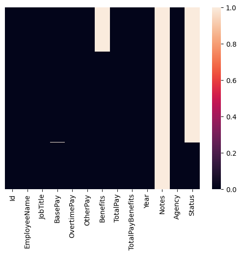

```python
sns.heatmap(df.isnull(),yticklabels=False)
```

```python
# 6
df.drop(["Id","Notes","Agency","Status"],axis = 1,inplace=True)
```

```python
df
```

|  | EmployeeName | JobTitle | BasePay | OvertimePay | OtherPay | Benefits | TotalPay | TotalPayBenefits | Year |
| --- | --- | --- | --- | --- | --- | --- | --- | --- | --- |
| 0 | NATHANIEL FORD | GENERAL MANAGER-METROPOLITAN TRANSIT AUTHORITY | 167411.18 | 0.0 | 400184.25 | NaN | 567595.43 | 567595.43 | 2011 |
| 1 | GARY JIMENEZ | CAPTAIN III (POLICE DEPARTMENT) | 155966.02 | 245131.88 | 137811.38 | NaN | 538909.28 | 538909.28 | 2011 |
| 2 | ALBERT PARDINI | CAPTAIN III (POLICE DEPARTMENT) | 212739.13 | 106088.18 | 16452.6 | NaN | 335279.91 | 335279.91 | 2011 |
| 3 | CHRISTOPHER CHONG | WIRE ROPE CABLE MAINTENANCE MECHANIC | 77916.0 | 56120.71 | 198306.9 | NaN | 332343.61 | 332343.61 | 2011 |
| 4 | PATRICK GARDNER | DEPUTY CHIEF OF DEPARTMENT,(FIRE DEPARTMENT) | 134401.6 | 9737.0 | 182234.59 | NaN | 326373.19 | 326373.19 | 2011 |
| ... | ... | ... | ... | ... | ... | ... | ... | ... | ... |
| 148649 | Roy I Tillery | Custodian | 0.00 | 0.00 | 0.00 | 0.00 | 0.00 | 0.00 | 2014 |
| 148650 | Not provided | Not provided | Not Provided | Not Provided | Not Provided | Not Provided | 0.00 | 0.00 | 2014 |
| 148651 | Not provided | Not provided | Not Provided | Not Provided | Not Provided | Not Provided | 0.00 | 0.00 | 2014 |
| 148652 | Not provided | Not provided | Not Provided | Not Provided | Not Provided | Not Provided | 0.00 | 0.00 | 2014 |
| 148653 | Joe Lopez | Counselor, Log Cabin Ranch | 0.00 | 0.00 | -618.13 | 0.00 | -618.13 | -618.13 | 2014 |

148654 rows × 9 columns

```python
# 7
df.describe(include="all")
```

|  | EmployeeName | JobTitle | BasePay | OvertimePay | OtherPay | Benefits | TotalPay | TotalPayBenefits | Year |
| --- | --- | --- | --- | --- | --- | --- | --- | --- | --- |
| count | 148654 | 148654 | 148049.0 | 148654.0 | 148654.0 | 112495.0 | 148654.000000 | 148654.000000 | 148654.000000 |
| unique | 110811 | 2159 | 109900.0 | 66555.0 | 84968.0 | 99635.0 | NaN | NaN | NaN |
| top | Kevin Lee | Transit Operator | 0.0 | 0.0 | 0.0 | 0.0 | NaN | NaN | NaN |
| freq | 13 | 7036 | 875.0 | 66103.0 | 35218.0 | 1053.0 | NaN | NaN | NaN |
| mean | NaN | NaN | NaN | NaN | NaN | NaN | 74768.321972 | 93692.554811 | 2012.522643 |
| std | NaN | NaN | NaN | NaN | NaN | NaN | 50517.005274 | 62793.533483 | 1.117538 |
| min | NaN | NaN | NaN | NaN | NaN | NaN | -618.130000 | -618.130000 | 2011.000000 |
| 25% | NaN | NaN | NaN | NaN | NaN | NaN | 36168.995000 | 44065.650000 | 2012.000000 |
| 50% | NaN | NaN | NaN | NaN | NaN | NaN | 71426.610000 | 92404.090000 | 2013.000000 |
| 75% | NaN | NaN | NaN | NaN | NaN | NaN | 105839.135000 | 132876.450000 | 2014.000000 |
| max | NaN | NaN | NaN | NaN | NaN | NaN | 567595.430000 | 567595.430000 | 2014.000000 |

```python
# 8
df.EmployeeName.value_counts().head()
```

```
Kevin Lee       13
Richard Lee     11
Steven Lee      11
William Wong    11
Stanley Lee      9
Name: EmployeeName, dtype: int64
```

```python
# 9
df.JobTitle.nunique()
```

```
2159
```

```python
# 10
df["JobTitle"].str.contains("Captain",case = False).sum()
```

```
552
```

```python
# 11
df[df["JobTitle"].str.contains("fire department",case = False)]["EmployeeName"]
```

```
4              PATRICK GARDNER
6                    ALSON LEE
8               MICHAEL MORRIS
9           JOANNE HAYES-WHITE
10               ARTHUR KENNEY
                  ...
32623             JAMES BARDEN
36162       Joanne Hayes-White
72926     Joanne M Hayes-White
102303          Robert E Evans
110535    Joanne M Hayes-White
Name: EmployeeName, Length: 226, dtype: object
```

```python
# 12
df["BasePay"] = df["BasePay"].replace("Not Provided",0)

df["BasePay"] = pd.to_numeric(df["BasePay"])
df.agg({"BasePay":["min","max","mean"]})
```

|  | BasePay |
| --- | --- |
| min | -166.010000 |
| max | 319275.010000 |
| mean | 66323.656854 |

```python
# 13
df["EmployeeName"] = df["EmployeeName"].replace("Not Provided",np.nan)
df
```

|  | EmployeeName | JobTitle | BasePay | OvertimePay | OtherPay | Benefits | TotalPay | TotalPayBenefits | Year |
| --- | --- | --- | --- | --- | --- | --- | --- | --- | --- |
| 0 | NATHANIEL FORD | GENERAL MANAGER-METROPOLITAN TRANSIT AUTHORITY | 167411.18 | 0.0 | 400184.25 | NaN | 567595.43 | 567595.43 | 2011 |
| 1 | GARY JIMENEZ | CAPTAIN III (POLICE DEPARTMENT) | 155966.02 | 245131.88 | 137811.38 | NaN | 538909.28 | 538909.28 | 2011 |
| 2 | ALBERT PARDINI | CAPTAIN III (POLICE DEPARTMENT) | 212739.13 | 106088.18 | 16452.6 | NaN | 335279.91 | 335279.91 | 2011 |
| 3 | CHRISTOPHER CHONG | WIRE ROPE CABLE MAINTENANCE MECHANIC | 77916.00 | 56120.71 | 198306.9 | NaN | 332343.61 | 332343.61 | 2011 |
| 4 | PATRICK GARDNER | DEPUTY CHIEF OF DEPARTMENT,(FIRE DEPARTMENT) | 134401.60 | 9737.0 | 182234.59 | NaN | 326373.19 | 326373.19 | 2011 |
| ... | ... | ... | ... | ... | ... | ... | ... | ... | ... |
| 148649 | Roy I Tillery | Custodian | 0.00 | 0.00 | 0.00 | 0.00 | 0.00 | 0.00 | 2014 |
| 148650 | Not provided | Not provided | 0.00 | Not Provided | Not Provided | Not Provided | 0.00 | 0.00 | 2014 |
| 148651 | Not provided | Not provided | 0.00 | Not Provided | Not Provided | Not Provided | 0.00 | 0.00 | 2014 |
| 148652 | Not provided | Not provided | 0.00 | Not Provided | Not Provided | Not Provided | 0.00 | 0.00 | 2014 |
| 148653 | Joe Lopez | Counselor, Log Cabin Ranch | 0.00 | 0.00 | -618.13 | 0.00 | -618.13 | -618.13 | 2014 |

148654 rows × 9 columns

```python
# 14
df = df.dropna(thresh=6)
df
```

|  | EmployeeName | JobTitle | BasePay | OvertimePay | OtherPay | Benefits | TotalPay | TotalPayBenefits | Year |
| --- | --- | --- | --- | --- | --- | --- | --- | --- | --- |
| 0 | NATHANIEL FORD | GENERAL MANAGER-METROPOLITAN TRANSIT AUTHORITY | 167411.18 | 0.0 | 400184.25 | NaN | 567595.43 | 567595.43 | 2011 |
| 1 | GARY JIMENEZ | CAPTAIN III (POLICE DEPARTMENT) | 155966.02 | 245131.88 | 137811.38 | NaN | 538909.28 | 538909.28 | 2011 |
| 2 | ALBERT PARDINI | CAPTAIN III (POLICE DEPARTMENT) | 212739.13 | 106088.18 | 16452.6 | NaN | 335279.91 | 335279.91 | 2011 |
| 3 | CHRISTOPHER CHONG | WIRE ROPE CABLE MAINTENANCE MECHANIC | 77916.00 | 56120.71 | 198306.9 | NaN | 332343.61 | 332343.61 | 2011 |
| 4 | PATRICK GARDNER | DEPUTY CHIEF OF DEPARTMENT,(FIRE DEPARTMENT) | 134401.60 | 9737.0 | 182234.59 | NaN | 326373.19 | 326373.19 | 2011 |
| ... | ... | ... | ... | ... | ... | ... | ... | ... | ... |
| 148649 | Roy I Tillery | Custodian | 0.00 | 0.00 | 0.00 | 0.00 | 0.00 | 0.00 | 2014 |
| 148650 | Not provided | Not provided | 0.00 | Not Provided | Not Provided | Not Provided | 0.00 | 0.00 | 2014 |
| 148651 | Not provided | Not provided | 0.00 | Not Provided | Not Provided | Not Provided | 0.00 | 0.00 | 2014 |
| 148652 | Not provided | Not provided | 0.00 | Not Provided | Not Provided | Not Provided | 0.00 | 0.00 | 2014 |
| 148653 | Joe Lopez | Counselor, Log Cabin Ranch | 0.00 | 0.00 | -618.13 | 0.00 | -618.13 | -618.13 | 2014 |

148654 rows × 9 columns

```python
# 15
df[df["EmployeeName"].isin(["ALBERT PARDINI"])]["JobTitle"]
```

```
2    CAPTAIN III (POLICE DEPARTMENT)
Name: JobTitle, dtype: object
```

```python
# 16
df[df["EmployeeName"] == "ALBERT PARDINI"]["TotalPayBenefits"]
```

```
2    335279.91
Name: TotalPayBenefits, dtype: float64
```

```python
# 17
df.BasePay.idxmax()
df.iloc[72925]["EmployeeName"]
```

```
'Gregory P Suhr'
```

```python
#18
df.groupby("Year").BasePay.mean()
```

```
Year
2011    63595.956517
2012    65436.406857
2013    69630.030216
2014    66557.437750
Name: BasePay, dtype: float64
```

```python
#19
df.groupby("JobTitle").BasePay.mean()
```

```
JobTitle
ACCOUNT CLERK                                     43300.806506
ACCOUNTANT                                        46643.172000
ACCOUNTANT INTERN                                 28732.663958
ACPO,JuvP, Juv Prob (SFERS)                       62290.780000
ACUPUNCTURIST                                     66374.400000
                                                      ...
X-RAY LABORATORY AIDE                             47664.773077
X-Ray Laboratory Aide                             46086.387100
YOUTH COMMISSION ADVISOR, BOARD OF SUPERVISORS    52609.910000
Youth Comm Advisor                                39077.957500
ZOO CURATOR                                       43148.000000
Name: BasePay, Length: 2159, dtype: float64
```

```python
#20
df[df.JobTitle == "ACCOUNTANT"].BasePay.mean()
```

```
46643.172
```

```python
#21
df.JobTitle.value_counts().head()
```

```
Transit Operator                7036
Special Nurse                   4389
Registered Nurse                3736
Public Svc Aide-Public Works    2518
Police Officer 3                2421
Name: JobTitle, dtype: int64
```